# Model fit

Piotr Król

23 08 2021

Content:

- 670 items model
  - Items fit
  - Local dependence
- Cramer’s V for responses
- 667 items model

```r
library(mirt)
library(DescTools) #For classical Cramer's V calculation
```

Load already prepared data (data_preparation.R) :

```r
responses_demo <- read.csv("Data/responses_demo.csv", encoding = "UTF-8")
responses <- as.matrix(responses_demo[,5:ncol(responses_demo)])
cdi <- read.csv("Data/cdi.csv", encoding = "UTF-8")
```

# 670 items model

Table of log-likelihoods and quadratures (cycles were increased properly to reach convergence):

| Quadratures | LogLik |
| --- | --- |
| 15 | -472591.2 |
| 61 | -463630.5 |
| 151 | -462896.9 |
| 301 | -462860.8 |
| 451 | -462860.681 |
| 601 | -462860.656 |

Based on 3rd report - “Quadratures” from 28.06.2021

601 quadrature points seems to be an optimal number - differece in LogLik is really marginal.

Create model:

```r
mod <- mirt(data = responses, model = 1, SE = TRUE, quadpts = 601, technical = list(NCYCLES = 10000))
save(mod, file = "Data/mod")
```

```r
mod
```

```
##
## Call:
## mirt(data = responses, model = 1, SE = TRUE, quadpts = 601, technical = list(NCYCLES = 10000))
##
## Full-information item factor analysis with 1 factor(s).
## Converged within 1e-04 tolerance after 2652 EM iterations.
## mirt version: 1.34
## M-step optimizer: BFGS
## EM acceleration: Ramsay
## Number of rectangular quadrature: 601
## Latent density type: Gaussian
##
## Information matrix estimated with method: Oakes
## Second-order test: model is a possible local maximum
## Condition number of information matrix =  2310.672
##
## Log-likelihood = -462860.7
## Estimated parameters: 1340
## AIC = 928401.3; AICc = 932160.6
## BIC = 936092.1; SABIC = 931834.6
## G2 (9999998660) = 890631.4, p = 1
## RMSEA = 0, CFI = NaN, TLI = NaN
```

## Items fit

```r
itemfit <- itemfit(mod, method = "MAP") #Use default S_X2 statistic and MAP ability estimation
```

```r
head(itemfit)
```

```
##    item    S_X2 df.S_X2 RMSEA.S_X2 p.S_X2
## 1 item1 346.844     355      0.000  0.612
## 2 item2 122.989     123      0.000  0.483
## 3 item3 216.953     190      0.008  0.088
## 4 item4 287.762     249      0.008  0.046
## 5 item5 127.229     133      0.000  0.625
## 6 item6 247.248     240      0.004  0.360
```

Misfits for p = 0.01:

```r
length(which(itemfit$p.S_X2 < 0.01))
```

```
## [1] 7
```

```r
itemfit[itemfit$p.S_X2 < 0.01, ]
```

```
##        item    S_X2 df.S_X2 RMSEA.S_X2 p.S_X2
## 204 item204 300.783     238      0.011  0.004
## 392 item392 337.266     253      0.012  0.000
## 417 item417 293.811     222      0.012  0.001
## 456 item456 189.726     143      0.012  0.005
## 463 item463 359.082     284      0.011  0.002
## 486 item486 176.611     132      0.012  0.006
## 652 item652 422.019     329      0.011  0.000
```

```r
cdi[row.names(itemfit[itemfit$p.S_X2 < 0.01, ]), ]
```

```
##             category number.ws number.wg       position
## 204       Z08.w_domu       204       138         balkon
## 392 Z14.przymiotniki       392       264         gorący
## 417   Z15.przysłówki       417       264         gorąco
## 456   Z16.czasowniki       456        NA krzyczeć.wołać
## 463   Z16.czasowniki       463       304      mieć..ma.
## 486   Z16.czasowniki       486        NA       pożyczyć
## 652     Z24.przyimki       652        NA              o
```

Misfits for p = 0.001:

```r
length(which(itemfit$p.S_X2 < 0.001))
```

```
## [1] 3
```

```r
itemfit[itemfit$p.S_X2 < 0.001, ]
```

```
##        item    S_X2 df.S_X2 RMSEA.S_X2 p.S_X2
## 392 item392 337.266     253      0.012  0.000
## 417 item417 293.811     222      0.012  0.001
## 652 item652 422.019     329      0.011  0.000
```

```r
cdi[row.names(itemfit[itemfit$p.S_X2 < 0.001, ]), ]
```

```
##             category number.ws number.wg position
## 392 Z14.przymiotniki       392       264   gorący
## 417   Z15.przysłówki       417       264   gorąco
## 652     Z24.przyimki       652        NA        o
```

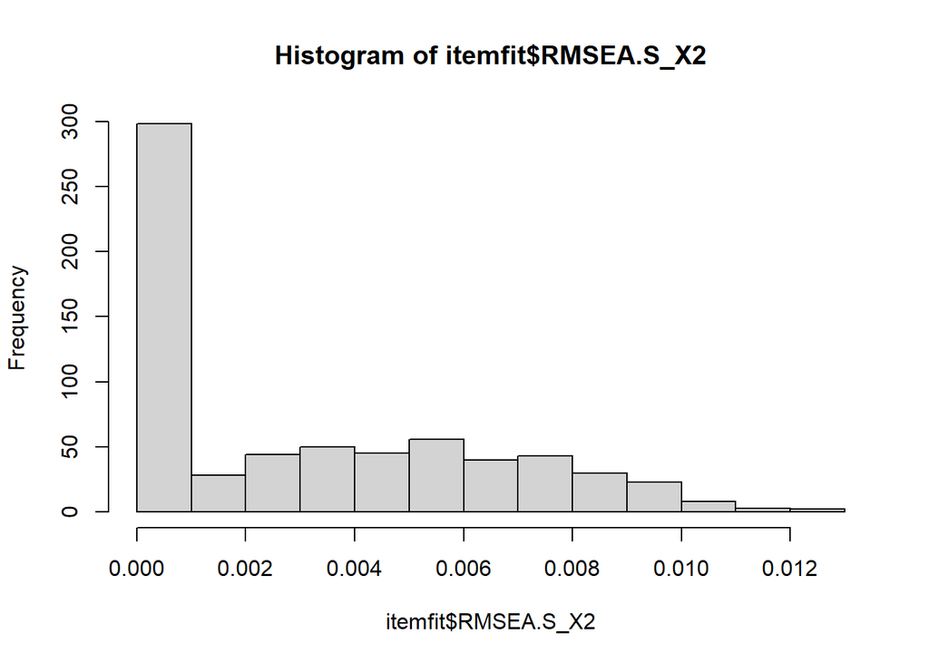

```r
hist(itemfit$RMSEA.S_X2)
```

## Local dependence

### Residuals

“By default, residuals() computes the local dependence (LD) pairwise statistic between each pair of items, which is very similar to a signed 2 value (Chen and Thissen 1997). Also, a standardized version of the LD statistic (Cramer’s V) is printed above the diagonal to aid in interpretation when items contain more than two response options and hence more degrees of freedom” ~ mirt documentation

```r
residuals <- residuals(mod)
```

```r
residuals_up <- residuals
residuals_down <- residuals
residuals_up[lower.tri(residuals_up)] <- NA
residuals_down[upper.tri(residuals_down)] <- NA
```

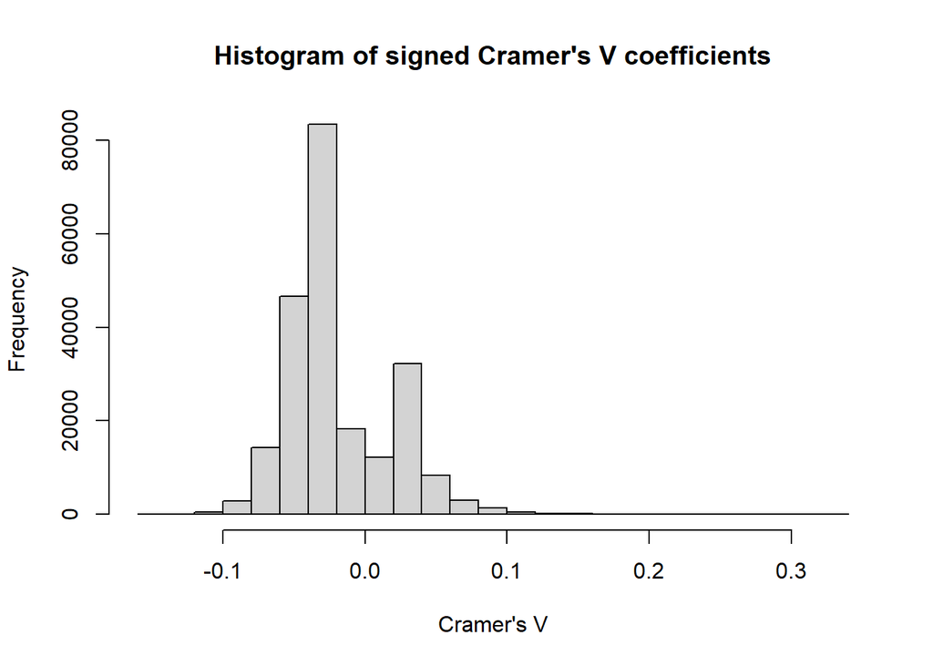

```r
hist(residuals_up, main="Histogram of signed Cramer's V coefficients", xlab= "Cramer's V")
```

```r
summary(as.vector(residuals_up))
```

```
##    Min. 1st Qu.  Median    Mean 3rd Qu.    Max.    NA's
##   -0.16   -0.04   -0.03   -0.02    0.01    0.33  224785
```

Check positions with the highest Cramer’s V:

```r
indexes <- arrayInd(which(residuals_up > 0.3), dim(residuals))
data.frame(pos1 = cdi[indexes[, 1], "position"], pos2 = cdi[indexes[, 2], "position"], CramersV = residuals_up[indexes])
```

```
##             pos1               pos2  CramersV
## 1        mee.bee        muu..krowa. 0.3044578
## 2          gę.gę pi.pi.pi.ćwir.ćwir 0.3112351
## 3        mee.bee pi.pi.pi.ćwir.ćwir 0.3105789
## 4            tak                nie 0.3285315
## 5 z.tyłu.do.tyłu z.przodu.do.przodu 0.3217046
## 6    on..mu..go.      ona..jej..ją. 0.3232634
## 7           jego                jej 0.3091598
## 8              a                  i 0.3121665
```

Check positions with the lowest Cramer’s V:

```r
indexes <- arrayInd(which(residuals_up < -0.14), dim(residuals))
data.frame(pos1 = cdi[indexes[, 1], "position"], pos2 = cdi[indexes[, 2], "position"], CramersV = residuals_up[indexes])
```

```
##                pos1     pos2   CramersV
## 1              ryba     stąd -0.1460721
## 2    miś.niedźwiedź    teraz -0.1487986
## 3 pieluszka.pampers niektóry -0.1503295
## 4              słoń    przed -0.1476706
## 5             picie        a -0.1597261
```

Check LD statistic:

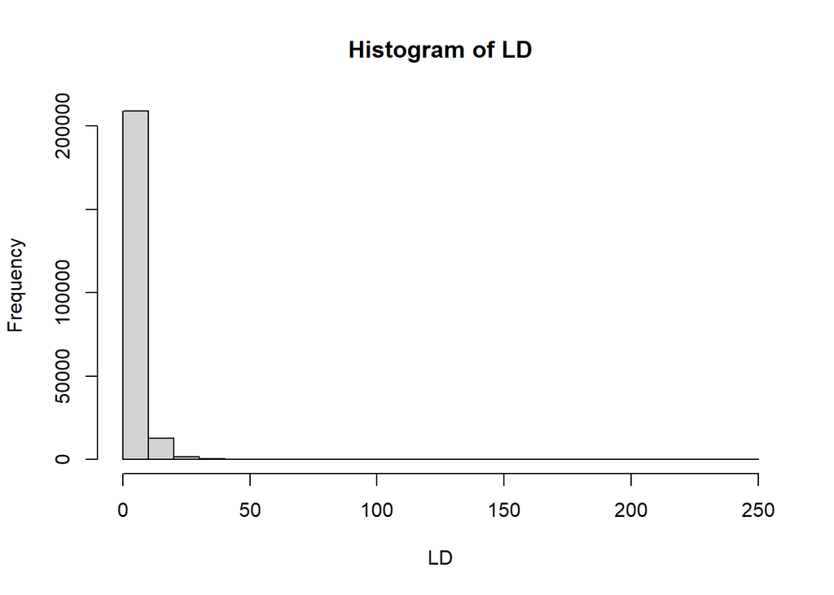

```r
hist(residuals_down, main="Histogram of LD", xlab= "LD")
```

```r
summary(as.vector(residuals_down))
```

```
##    Min. 1st Qu.  Median    Mean 3rd Qu.    Max.    NA's
##    0.00    1.32    2.51    3.92    4.84  247.92  224785
```

Check positions with the highest LD:

```r
indexes <- arrayInd(which(residuals_down > 200), dim(residuals))
data.frame(pos1 = cdi[indexes[, 1], "position"], pos2 = cdi[indexes[, 2], "position"], Chi.sq = residuals_down[indexes])
```

```
##                  pos1           pos2   Chi.sq
## 1  pi.pi.pi.ćwir.ćwir          gę.gę 222.5042
## 2         muu..krowa.        mee.bee 212.9194
## 3  pi.pi.pi.ćwir.ćwir        mee.bee 221.5669
## 4      tralala.lalala    bam.bum.bęc 201.4367
## 5          tata.tatuś   mama.mamusia 205.4690
## 6                 nie            tak 247.9220
## 7  z.przodu.do.przodu z.tyłu.do.tyłu 237.7254
## 8       ona..jej..ją.    on..mu..go. 240.0347
## 9                 jej           jego 219.5467
## 10                  i              a 223.8378
```

How many items have LD > 100 with at least one item:

```r
indexes <- arrayInd(which(residuals_down > 100), dim(residuals))
rows <- indexes[, 1]
columns <- indexes[, 1]
unique <- unique(c(unique(rows), unique(columns)))
length(unique)
```

```
## [1] 42
```

Check positions with the lowest LD:

```r
indexes <- arrayInd(which(residuals_down < 0.009), dim(residuals))
data.frame(pos1 = cdi[indexes[, 1], "position"], pos2 = cdi[indexes[, 2], "position"], Chi.sq = residuals_down[indexes])
```

```
##       pos1    pos2      Chi.sq
## 1  smoczek   gę.gę 0.003578757
## 2  chrupki autobus 0.004732596
## 3    pępek chrupki 0.007944320
## 4  smoczek herbata 0.006042689
## 5    sklep   lizak 0.007779428
## 6 huśtawka butelka 0.003695412
## 7       do   kubek 0.006967818
## 8    zimno   sklep 0.004494238
## 9        a    mało 0.008992875
```

# Cramer’s V for responses matrix

Check classical Cramer’s V values:

```r
cramersV <- PairApply(responses, FUN = CramerV)
cramersV[lower.tri(cramersV)] <- NA
diag(cramersV) <- NA
```

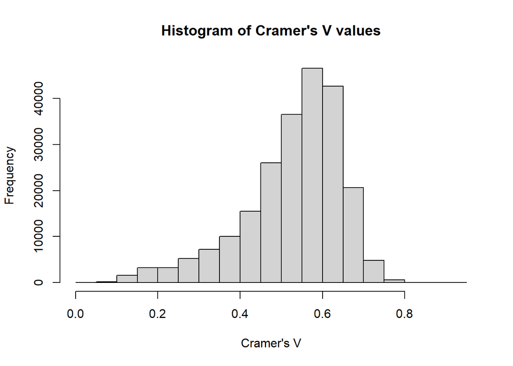

```r
hist(cramersV, main="Histogram of Cramer's V values", xlab= "Cramer's V")
```

How many items correlate higher than 0.8 with at least one other item:

```r
indexes <- arrayInd(which(cramersV > 0.8), dim(cramersV))
rows <- indexes[, 1]
columns <- indexes[, 1]
unique <- unique(c(unique(rows), unique(columns)))
length(unique)
```

```
## [1] 15
```

What are these items:

```r
indexes <- arrayInd(which(cramersV > 0.8), dim(cramersV))
data.frame(pos1 = cdi[indexes[, 1], "position"], pos2 = cdi[indexes[, 2], "position"], cramersV = cramersV[indexes])
```

```
##                pos1               pos2  cramersV
## 1           kuchnia            lodówka 0.8008774
## 2           lodówka           łazienka 0.8162790
## 3               pan               pani 0.8029523
## 4         śniadanie              obiad 0.8305280
## 5         śniadanie            kolacja 0.8661703
## 6             obiad            kolacja 0.8145996
## 7             biały             czarny 0.8181279
## 8            czarny           czerwony 0.8387322
## 9           otwarty          zamknięty 0.8013162
## 10         przykryć          przynieść 0.8177750
## 11   włożyć.założyć           wyrzucić 0.8039820
## 12         wyrzucić            wytrzeć 0.8148723
## 13           zgubić            znaleźć 0.8066401
## 14           złapać            znaleźć 0.8111410
## 15 na.górę.na.górze     na.dół.na.dole 0.8348244
## 16   z.tyłu.do.tyłu z.przodu.do.przodu 0.9035778
```

# 667 items model

Create model on a restricted set of items (remove items marked as misfits for p < 0.001):

```r
items_to_remove <- as.numeric(row.names(itemfit[itemfit$p.S_X2 < 0.001, ]))
save(items_to_remove, file="Data/items_to_remove")
```

```r
items_to_remove
```

```
## [1] 392 417 652
```

```r
mod_r <- mirt(data = responses[, -c(392, 417, 652)], model = 1, SE = TRUE, quadpts = 601, technical = list(NCYCLES = 10000))
save(mod_r, file="Data/mod_r")
```

```r
mod_r
```

```
##
## Call:
## mirt(data = responses[, -c(392, 417, 652)], model = 1, SE = TRUE,
##     quadpts = 601, technical = list(NCYCLES = 10000))
##
## Full-information item factor analysis with 1 factor(s).
## Converged within 1e-04 tolerance after 2700 EM iterations.
## mirt version: 1.34
## M-step optimizer: BFGS
## EM acceleration: Ramsay
## Number of rectangular quadrature: 601
## Latent density type: Gaussian
##
## Information matrix estimated with method: Oakes
## Second-order test: model is a possible local maximum
## Condition number of information matrix =  2311.374
##
## Log-likelihood = -460055
## Estimated parameters: 1334
## AIC = 922778.1; AICc = 926480.5
## BIC = 930434.4; SABIC = 926196
## G2 (9999998666) = 885020.2, p = 1
## RMSEA = 0, CFI = NaN, TLI = NaN
```